# Day 1 - ML course

Maximilian Pichler, Florian Hartig

6/21/2019

## TensorFlow ecosystem

At the moment the [TensorFlow](https://www.tensorflow.org/) is rapdily changing. With TF1.x, [Keras](https://keras.io/) is a fully integrated sub-module of TF. Keras is high level neural-network API on Top of TF. Keras simplifies building, training, evaluation and predicting of all kinds of neural networks.

The RStudio team developed R bindings for the TF ecosystem with the TensorFlow and Keras package. For documentation and help see: + [R-TensorFlow](https://tensorflow.rstudio.com/) + [R-Keras](https://keras.rstudio.com/) + [TensorFlow (Python API)](https://www.tensorflow.org/versions/r2.0/api_docs/python/tf). The python API documentation has a more detailed documentation with examples

### TensorFlow Core

Loading the R-tensorflow package will link the python tensorflow API to the ‘tf’ object. The syntax will seem, at first, weird but is derived from python (OOP Style).

```r
library(tensorflow) # will load and link the python api to the "tf" in the enviornment. The API can be called by tf$...
tf$enable_eager_execution()
tf$print("TensorFlow: Hello World!")
print(tf$version) # Base R methods fully support TF objects and Operations.
```

```
## Module(tensorflow._api.v1.version)
```

Before we can exploit TF operations, we have to export or create explicitly tf tensors:

```r
# We create two scalar values
a = tf$constant(10.0) # R style: a = 10.0
b = tf$constant(20.0) # R style: b = 20.0

c1 = tf$add(a, b)
print(c1)
```

```
## tf.Tensor(30.0, shape=(), dtype=float32)
```

```r
c2 = a + b # Default methods are available for TF operations ->  a+b returns a tf tensor
print(c2)
```

```
## tf.Tensor(30.0, shape=(), dtype=float32)
```

```r
c3 = tf$add(10.0, 20.0) # tf tensor as return type
print(c3)
```

```
## tf.Tensor(30.0, shape=(), dtype=float32)
```

```r
c4 = 10.0 + 20.0
print(c4) # Base R operation, return type is a R numeric
```

```
## [1] 30
```

Before we continue, we have to talk about data types. The above printed tf tensors have the dtype “float32”. TF is a highly optimized library written in C++. For speed up and safety, we have to set the dtypes of our operations. For more detailed information on dtypes read [Wikipedia](https://en.wikipedia.org/wiki/Data_type). Basically, there are four important dtypes:

- Integers: e.g. 10 (in R we can write 10L to get a explicit integer) -> count data
- Floating point: e.g. 10 -> real values
- Characters: e.g. “Hallo”
- Boolean: e.g. TRUE/FALSE or binary 0/1

In addition to the base dtypes, we can set how many memory the type should take up. For instance, TF supports 16, 32, and 64 Bits for floats. (This results in different precisions. But why should we use 16 or 32 bits for floats when today’s systems support 64 bits and we have more than enough RAM? -> GPU computation! Many GPU support only 32 bit floats and RAM is also limiting GPU computation).

**WARNING** In my experience, most of the errors occur because the R-Python interpreter (reticulate package) which transform our R numerics to the corresponding Python numerics changes the type if not explicitly set:

```r
a = tf$constant(1:10) # float or integer?
try(a/2)

# Better:
a = tf$constant(1:10, dtype = "float64") # set type directly in TF
try(a/2) # error again, our R-64bit numeric is cast to 32-float!

# We could solve that by using float32
a = tf$constant(1:10, dtype = "float32")
try(a/2)

# Best practise - Cast everything first to a TF tensor and set the type explicitly!
dtype = "float64"
a = tf$constant(1:10, dtype = dtype)
b = tf$constant(2, dtype = dtype)
a/b

# Also set the arguments explicitly to Integer:
try(
  tf$reshape(a, shape = list(2, 5)) # reshape vector into 2x5 Matrix
)
# ERROR because the argument types were cast wrongly!! Use always the explicit R integer type:

try(
  tf$reshape(a, shape = list(2L, 5L)) # reshape vector into 2x5 Matrix
)
```

Side note: I learned this lesssion the hard way after hours/days of debugging errors caused by wrong R-Py-TF casts.

You may have noticed that TF always return a Tensor of TF operations. If we want to work the the TF result in R we have to cast it back to a R type:

```r
a = tf$constant(1:10)
try(sum(a)) # no sum method implemented for tf tensors
```

```
## Error in sum(a) : invalid 'type' (environment) of argument
```

```r
# Cast back to R by:
a_R = a$numpy()
print(sum(a_R))
```

```
## [1] 55
```

### Exercise - 1: Simple RSSE optimization

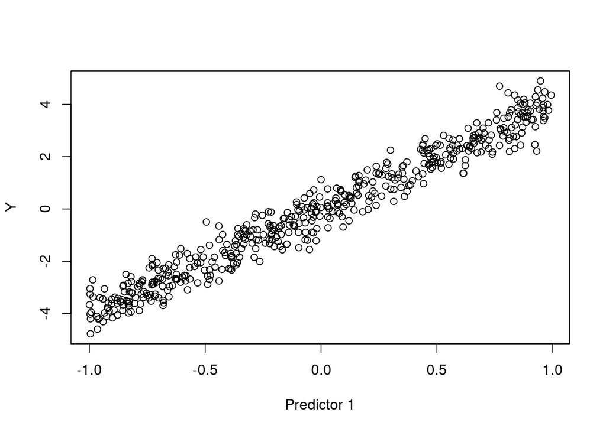

```r
set.seed(42)
n_predictors = 1L
n_observations = 500L
X = matrix(runif(n_predictors * n_observations, -1, 1), n_observations, n_predictors)
W = 4
Y = X %*% W + rnorm(n_observations, 0, 0.5)

plot(Y~X[,1], xlab = "Predictor 1", ylab = "Y")
```

```r
# R - Style:

RSSE = function(par){
  y_hat = X %*% par
  return(sum(y_hat-Y)^2)
}

(opt = optim(par = -1, lower = -15, upper = 15, fn = RSSE, method = "Brent")$par)
```

```
## [1] 5.196586
```

Export the operations in the RSSE to TF operations (Remember to return the tensor as tensor$numpy())

```r
# help:
# the tf$math module provides all required operations

RSSE_tf = function(par){
  # cast par vector to tensor:

  # calculate y_hat

  # calculate rsse

  return(rsse$numpy())
}

(opt = optim(par = -1, lower = -15, upper = 15, fn = RSSE_tf, method = "Brent")$par)
```

### Exercise - 1: Solution with Keras

Keras is a high level neural network API in the TF ecosyste and simplifies not only the model building but in particular the training. The Keras API is available by:

```r
library(keras)
print(keras::backend())
```

```
## Module(tensorflow.python.keras.backend)
```

Or by the RStudio keras package which is basically just a wrapper around the submodule. Fitting a model with keras involves three steps:

1. Build the model:
- Input shape
- Hidden layer definition
- Output shape
2. Compile the model:
- Define loss function
- Define Optimizer
3. Fitting:
- Train the model in n epochs

We will explain on Day 3 what or how neural networks work. For now, we will fit without a hidden layer, thus our model is just a linear model:

```r
# 1. Build the model:
model = keras_model_sequential()
model %>%
  layer_dense(units = 1L, input_shape = c(1L))
summary(model)


# 2. Compile model:
model %>%
  compile(loss = "mean_squared_error", optimizer = optimizer_adamax(0.01))

# 3. Training:
fit_history =
  model %>%
    fit(x = X, y = matrix(Y, ncol = 1L), epochs = 200L, verbose = 0L)
print(sapply(model$weights, function(w) w$numpy()))
plot(fit_history)
```

[output not shown]

## Machine Learning workflow

### Step 1: load and explore data

Boston housing data: target_variable: medv

| Var | Description |
| --- | --- |
| crim | per capita crime rate by town |
| zn | proportion of residential land zoned for lots over 25,000 sq.ft |
| indus | proportion of non-retail business acres per town |
| chas | Charles River dummy variable (= 1 if tract bounds river; 0 otherwise) |
| nox | nitric oxides concentration (parts per 10 million) |
| rm | average number of rooms per dwelling |
| age | proportion of owner-occupied units built prior to 1940 |
| dis | weighted distances to five Boston employment centres |
| rad | index of accessibility to radial highways |
| tax | full-value property-tax rate per USD 10,000 |
| ptratio | pupil-teacher ratio by town |
| b | 1000(B - 0.63)^2 where B is the proportion of blacks by town |
| lstat | percentage of lower status of the population |
| medv | median value of owner-occupied homes in USD 1000’s |

```r
housing = read.csv("data/BostonHousing.csv")
housing = housing[,-1]

summary(housing)
```

```
##       crim                zn             indus            chas
##  Min.   : 0.00632   Min.   :  0.00   Min.   : 0.46   Min.   :0.00000
##  1st Qu.: 0.08204   1st Qu.:  0.00   1st Qu.: 5.19   1st Qu.:0.00000
##  Median : 0.25651   Median :  0.00   Median : 9.69   Median :0.00000
##  Mean   : 3.61352   Mean   : 11.36   Mean   :11.14   Mean   :0.06917
##  3rd Qu.: 3.67708   3rd Qu.: 12.50   3rd Qu.:18.10   3rd Qu.:0.00000
##  Max.   :88.97620   Max.   :100.00   Max.   :27.74   Max.   :1.00000
##       nox               rm             age              dis
##  Min.   :0.3850   Min.   :3.561   Min.   :  2.90   Min.   : 1.130
##  1st Qu.:0.4490   1st Qu.:5.886   1st Qu.: 45.02   1st Qu.: 2.100
##  Median :0.5380   Median :6.208   Median : 77.50   Median : 3.207
##  Mean   :0.5547   Mean   :6.285   Mean   : 68.57   Mean   : 3.795
##  3rd Qu.:0.6240   3rd Qu.:6.623   3rd Qu.: 94.08   3rd Qu.: 5.188
##  Max.   :0.8710   Max.   :8.780   Max.   :100.00   Max.   :12.127
##       rad              tax           ptratio            b
##  Min.   : 1.000   Min.   :187.0   Min.   :12.60   Min.   :  0.32
##  1st Qu.: 4.000   1st Qu.:279.0   1st Qu.:17.40   1st Qu.:375.38
##  Median : 5.000   Median :330.0   Median :19.05   Median :391.44
##  Mean   : 9.549   Mean   :408.2   Mean   :18.46   Mean   :356.67
##  3rd Qu.:24.000   3rd Qu.:666.0   3rd Qu.:20.20   3rd Qu.:396.23
##  Max.   :24.000   Max.   :711.0   Max.   :22.00   Max.   :396.90
##      lstat            medv
##  Min.   : 1.73   Min.   : 5.00
##  1st Qu.: 6.95   1st Qu.:17.02
##  Median :11.36   Median :21.20
##  Mean   :12.65   Mean   :22.53
##  3rd Qu.:16.95   3rd Qu.:25.00
##  Max.   :37.97   Max.   :50.00
```

[figure not shown]

```r
par(mfrow = c(4,4))
for(i in 1:ncol(housing)){
  hist(housing[,i], main = colnames(housing)[i])
  abline(v = mean(housing[,i]) , col = "red")
}
```

### Step 2: Cleaning, prepocssing and splitting

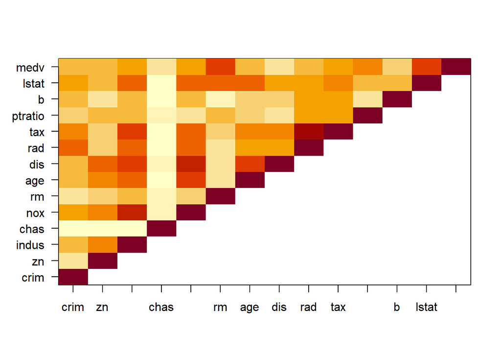

```r
correlations = cor(housing)
correlations[upper.tri(correlations)] = NA
image(t(abs(correlations)),xaxt = "n", yaxt = "n",useRaster = TRUE)
axis(1, at=seq(0,1,length.out=ncol(housing)), labels=colnames(housing), las= 1)
axis(2, at=seq(0,1,length.out=ncol(housing)), labels=colnames(housing), las= 2)
```

```r
# scale predictors
X = housing[,-which(colnames(housing) == "medv", arr.ind = TRUE)]
Y = housing[,which(colnames(housing) == "medv", arr.ind = TRUE)]

X = scale(X)

# split into training and testing datasets
indices = sample.int(nrow(X), 0.8*nrow(X),replace = FALSE)
train = list(X = X[indices, ], Y = Y[indices])
test = list(X = X[-indices, ], Y = Y[-indices])
```

### Step 3: Model fitting

```r
# 1. Build model
model = keras_model_sequential()
model %>%
  layer_dense(units = 20L,input_shape = c(ncol(X)), activation = "relu") %>%
  layer_dense(units = 20L, activation = "relu") %>%
  layer_dense(units = 1L)
summary(model)
```

```
## ___________________________________________________________________________
## Layer (type)                     Output Shape                  Param #
## ===========================================================================
## dense (Dense)                    (None, 20)                    280
## ___________________________________________________________________________
## dense_1 (Dense)                  (None, 20)                    420
## ___________________________________________________________________________
## dense_2 (Dense)                  (None, 1)                     21
## ===========================================================================
## Total params: 721
## Trainable params: 721
## Non-trainable params: 0
## ___________________________________________________________________________
```

```r
# 2. specify loss and optimizer
model %>%
  compile(loss = loss_mean_squared_error, optimizer = optimizer_adamax(0.01))

# 3. fit model on training data
fit_history =
  model %>%
    fit(x = train$X, y = matrix(train$Y, ncol = 1L), epochs = 100L, validation_data = list(test$X,matrix(test$Y, ncol = 1L)), verbose = 0L)

# lm:
data = data.frame(train$X, medv = train$Y)
lm = lm(medv~., data)
```

### Step 4: Evaluation

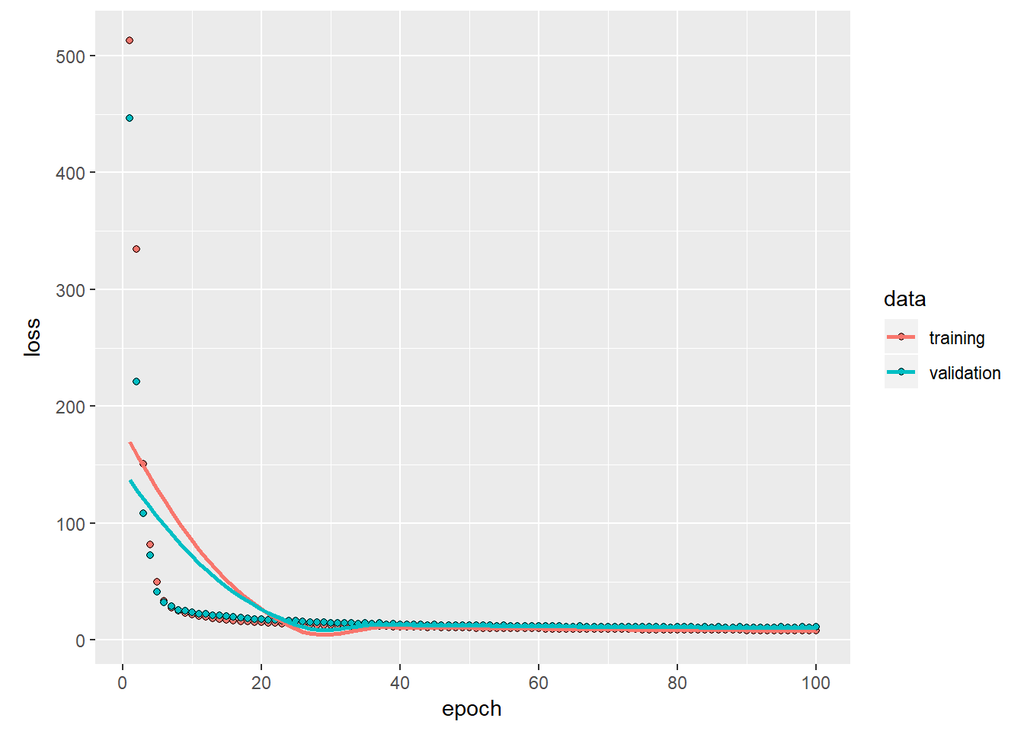

```r
plot(fit_history)
```

```r
model %>%
  evaluate(x = test$X, y = matrix(test$Y, ncol = 1L))
```

```
##     loss
## 11.02078
```

```r
pred_keras = predict(model, x = test$X)
pred_lm = predict(lm, newdata = data.frame(test$X))

Metrics::rmse(test$Y, pred_keras)
```

```
## [1] 3.319755
```

```r
Metrics::rmse(test$Y, matrix(pred_lm, ncol = 1L))
```

```
## [1] 5.187606
```

```r
#print(sapply(model$weights, function(w) w$numpy()))
print(coef(lm))
```

```
## (Intercept)        crim          zn       indus        chas         nox
## 22.59247933 -1.03573136  1.08450733  0.21875061  0.85340387 -2.18018946
##          rm         age         dis         rad         tax     ptratio
##  2.69920740 -0.09135267 -3.08073336  2.78068765 -2.05985270 -2.05474637
##           b       lstat
##  1.03594259 -3.69390663
```

### Exercise - 2: Titanc Dataset

- Load the data set
- Explore the data
- Preprocess (which columns to include/exclude, transform categorical into dummy variables)
- Fit keras model (is given)
- Fit glm (why glm here?)
- Evaluate on Titanic_test

```r
train = read.csv("data/Titanic_train.csv")
test = read.csv("data/Titanic_test.csv")
```

```r
model = keras_model_sequential()
model %>%
  layer_dense(units = 20L, activation = "relu", input_shape = ncol(train_x)) %>%
  layer_dense(units = 20L, activation = "relu") %>%
  layer_dense(units = 1L, activation = "sigmoid")

model %>%
  compile(loss = loss_binary_crossentropy, optimizer = optimizer_adamax())

fit_history =
  model %>%
    fit(x = train_x, y = train_y, epochs = 100L)
```